# Call-in/Cancellation Experiment Analysis

**Goal**: Evaluate the performance of the call-in initiative.

### Importing the csv files

```r
testSamples <- read.csv("//data-ge02/Users/ftinawi/Documents/Bogoss_directory/testSamples.csv")
transData <- read.csv("//data-ge02/Users/ftinawi/Documents/Bogoss_directory/transData.csv")
```

### Preparing the data

```r
#install.packages("plyr")
library(plyr)
#install.packages("dplyr")
library(dplyr)
#install.packages("sqldf")
library(sqldf)
#install.packages("BSDA")
library(BSDA)         # for the z-test function
```

We merge the two data sets together:

```r
transFull <- merge(x = testSamples, y = transData, by.x = "sample_id", by.y = "sample_id", all.x = TRUE);
transFull[10:20,]
```

```
##    sample_id test_group transaction_id transaction_type transaction_amount
## 10        10          0             NA             <NA>                 NA
## 11        11          1       52346326           REBILL              24.95
## 12        11          1       52346327           REBILL              24.95
## 13        12          0             NA             <NA>                 NA
## 14        13          0             NA             <NA>                 NA
## 15        14          0             NA             <NA>                 NA
## 16        15          0             NA             <NA>                 NA
## 17        16          1             NA             <NA>                 NA
## 18        17          0             NA             <NA>                 NA
## 19        18          0             NA             <NA>                 NA
## 20        19          0             NA             <NA>                 NA
```

Let’s see the distribution per transaction type.

```r
count(transFull,transFull$transaction_type)
```

```
## # A tibble: 4 x 2
##   `transFull$transaction_type`     n
##                         <fctr> <int>
## 1                   CHARGEBACK   163
## 2                       REBILL  6961
## 3                       REFUND   306
## 4                         <NA> 57007
```

### Approximation of the probability distribution

Grouping in regard to the test type:

```r
testGroup <- group_by(testSamples, test_group)
summarise(testGroup,ct=length(test_group))
```

```
## # A tibble: 2 x 2
##   test_group    ct
##        <int> <int>
## 1          0 44886
## 2          1 14835
```

Defining some constants:

```r
# Size of the population
n = dim(testSamples)[1]
n
# Size of the test group
m = summarise(testGroup,ct=length(test_group))[[2,2]]
m
```

```
## [1] 59721
## [1] 14835
```

Since n is large enough, we can estimate p and q as follows:

```r
# Estimated probability of being selected in the test group
p <- m/n
p
q <- (1-p)
q
```

```
## [1] 0.2484051
## [1] 0.7515949
```

Validate conditions to approximate binomial with normal distribution:

```r
n*p > 10
n*q > 10
```

```
## [1] TRUE
## [1] TRUE
```

Using the Central limit theorem and $Z = \frac{X -\mu}{\sigma}$, we have the following normal distribution $N\sim (14835,105.6)$.

```r
mu <- n*p
mu
sig <- sqrt(n*p*q)
sig
```

```
## [1] 14835
## [1] 105.5931
```

We plot the graph of the curve.

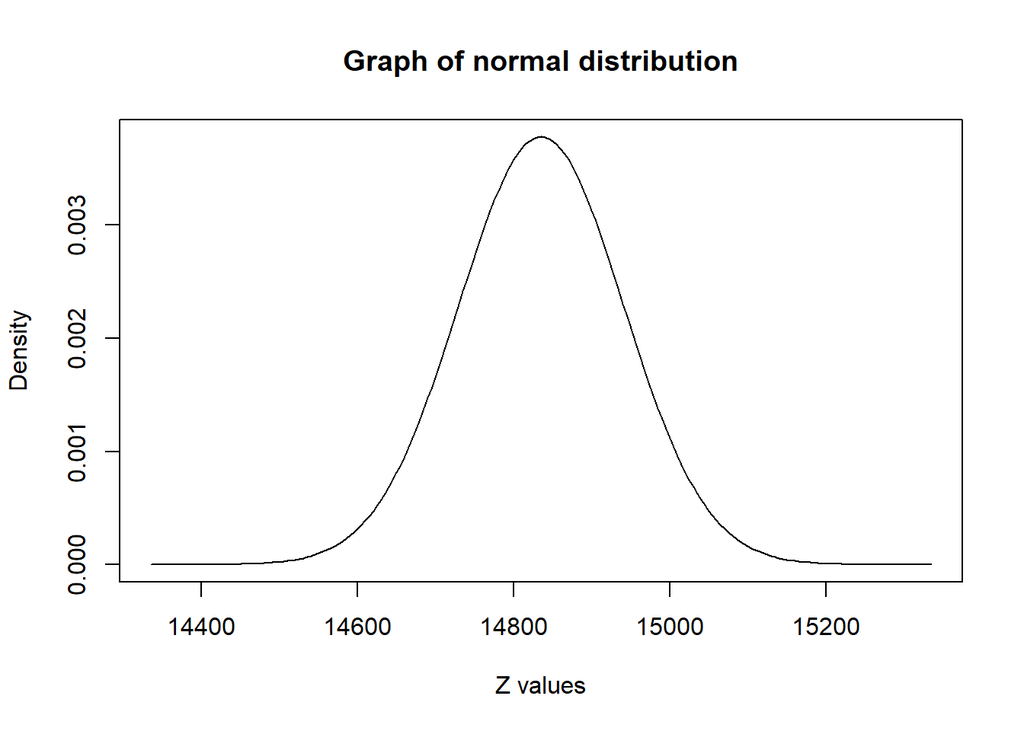

```r
x <- seq(mu - 500,mu + 500, by = 5)
y <- dnorm(x, mean = mu, sd = sig)
plot (x, y, type = "l", xlab = "Z values", ylab = "Density", main = "Graph of normal distribution")
```

### Looking into the rebills

We now look deeper into the call-in users and their purchasing habits.

#### Proportion of rebills

We group the rebills and revenues by test type and transaction type.

```r
trxGrp <- group_by(transFull, sample_id, test_group, transaction_type)
transFullGrp <- summarise(trxGrp, trxTT = length(sample_id), revTT = sum(transaction_amount))
head(transFullGrp,15)
```

```
## # A tibble: 15 x 5
## # Groups:   sample_id, test_group [15]
##    sample_id test_group transaction_type trxTT revTT
##        <int>      <int>           <fctr> <int> <dbl>
##  1         1          0             <NA>     1    NA
##  2         2          1             <NA>     1    NA
##  3         3          0             <NA>     1    NA
##  4         4          1             <NA>     1    NA
##  5         5          1             <NA>     1    NA
##  6         6          0             <NA>     1    NA
##  7         7          0             <NA>     1    NA
##  8         8          1             <NA>     1    NA
##  9         9          0             <NA>     1    NA
## 10        10          0             <NA>     1    NA
## 11        11          1           REBILL     2  49.9
## 12        12          0             <NA>     1    NA
## 13        13          0             <NA>     1    NA
## 14        14          0             <NA>     1    NA
## 15        15          0             <NA>     1    NA
```

Let’s compute the ratio of call-in users that lead to at least one rebill.

```r
CallWithRebill <- dim(transFullGrp[which(transFullGrp$test_group == 1 & transFullGrp$transaction_type == 'REBILL'),])[1]
CallWithRebill
CallWithRebill / m
```

```
## [1] 1556
## [1] 0.1048871
```

We compare with the web-form users.

```r
WebWithRebill <- dim(transFullGrp[which(transFullGrp$test_group == 0 & transFullGrp$transaction_type == 'REBILL'),])[1]
WebWithRebill/(n-m)
#We divide the two proportions
(CallWithRebill/m) / (WebWithRebill/(n-m))
```

```
## [1] 0.02096422
## [1] 5.003148
```

**Observation**: Call-in users are 5 times more likely to generate a rebill versus the web form users.  
Is this observation statistically significant?

Let the null hypothesis be:

$H_{0}$ = proportion of rebills from call-in users is similar than the one from users using the web form

and the alternate hypothesis:

$H_{a}$ = proportion of rebills from call-in users is greater than the one from users using the web form

We apply the 2 samples test for proportions:

```r
res <- prop.test(c(CallWithRebill,WebWithRebill), c(m,n-m), alternative = "greater")
res
```

```
##
##  2-sample test for equality of proportions with continuity
##  correction
##
## data:  c(CallWithRebill, WebWithRebill) out of c(m, n - m)
## X-squared = 1958.1, df = 1, p-value < 2.2e-16
## alternative hypothesis: greater
## 95 percent confidence interval:
##  0.07959321 1.00000000
## sample estimates:
##     prop 1     prop 2
## 0.10488709 0.02096422
```

```r
# we verify that the p-value is less than the significance level of 5%
res$p.value < 0.05
```

```
## [1] TRUE
```

With a p-value smaller than 2.2e-16 and well below the 5% significance level, we reject the null hypothesis.

**Conclusion**: we can state that call-in users will generate more rebills than web-form users with 95% confidence.

#### Average revenue per user

We define some useful values:

```r
# Denormalized dataframe with rebills and revenues per user
trxDenorm <- sqldf("select sample_id, test_group, count(*) ct_tt
        , ifnull(sum(t.transaction_type == 'REBILL'),0) as ct_rebill
        , ifnull(sum(t.transaction_type == 'CHARGEBACK'),0) as ct_chgbk
        , ifnull(sum(t.transaction_type == 'REFUND'),0) as ct_refund
        , ifnull(sum(t.transaction_amount),0) revenues
        , round(sum(t.transaction_type == 'CHARGEBACK') / sum(t.transaction_type == 'REBILL'), 4) chgbk_rate
        from transFull t
        group by t.sample_id, test_group")
head(trxDenorm)
```

```
##   sample_id test_group ct_tt ct_rebill ct_chgbk ct_refund revenues
## 1         1          0     1         0        0         0        0
## 2         2          1     1         0        0         0        0
## 3         3          0     1         0        0         0        0
## 4         4          1     1         0        0         0        0
## 5         5          1     1         0        0         0        0
## 6         6          0     1         0        0         0        0
##   chgbk_rate
## 1         NA
## 2         NA
## 3         NA
## 4         NA
## 5         NA
## 6         NA
```

Let’s investigate now the revenue average and standard deviation among the two groups.

```r
CallAvgRev <- mean(trxDenorm$revenues[trxDenorm$test_group == 1])
CallAvgRev
WebAvgRev <- mean(trxDenorm$revenues[trxDenorm$test_group == 0])
WebAvgRev
CallSdRev <- sd(trxDenorm$revenues[trxDenorm$test_group == 1])
CallSdRev
WebSdRev <- sd(trxDenorm$revenues[trxDenorm$test_group == 0])
WebSdRev
```

```
## [1] 6.432996
## [1] 2.00149
## [1] 25.70531
## [1] 20.4474
```

**Observation**: Call-in users generate revenues three times greater than the web form users.  
Is this observation statistically significant?

Let the null hypothesis be:

$H_{0}$ = average revenue from call-in users is similar to the one from users using the web form

and the alternate hypothesis:

$H_{a}$ = average revenue from call-in users is greater then the one from users using the web form

Using the samples standard deviations to estimate the population standard deviations, we compute the z value:
$$z = \frac{\overline{x}_1 - \overline{x}_2}{\sqrt{s_1^2/n_1 + s_2^2/n_2}}$$

```r
z = (CallAvgRev - WebAvgRev)/sqrt(CallSdRev^2/m + WebSdRev^2/(n-m))
z
```

```
## [1] 19.09574
```

```r
# Verify that z is in the confidence interval
z > 1.96
```

```
## [1] TRUE
```

**Conclusion**: we can state that call-in users will generate more revenues than web-form users with 95% confidence.

#### Chargeback rate

Let’s compute the chargeback rates.  
In order to do so we only keep the users with at least one rebill. The chargeback ratio wouldn’t make sense otherwise.

```r
# Only keep users with at list one rebill
trxWithRebill <- trxDenorm[trxDenorm$ct_rebill > 0,]
# There are 2497 users left
dim(trxWithRebill)
```

```
## [1] 2497    8
```

Compute mean and standard deviation.

```r
CallAvgCB <- mean(trxWithRebill$chgbk_rate[trxWithRebill$test_group == 1])
CallAvgCB
WebAvgCB <- mean(trxWithRebill$chgbk_rate[trxWithRebill$test_group == 0])
WebAvgCB
CallSdCB <- sd(trxWithRebill$chgbk_rate[trxWithRebill$test_group == 1])
CallSdCB
WebSdCB <- sd(trxWithRebill$chgbk_rate[trxWithRebill$test_group == 0])
WebSdCB
```

```
## [1] 0.003213368
## [1] 0.001062699
## [1] 0.05661362
## [1] 0.03259907
```

**Observation**: Chargeback rate for call-in users seems higher than for the web form users.  
Is this observation statistically significant?

We apply the z-test:

```r
res2 <- z.test(trxWithRebill$chgbk_rate[trxWithRebill$test_group == 1],trxWithRebill$chgbk_rate[trxWithRebill$test_group == 0],sigma.x = CallSdCB, sigma.y = WebSdCB,alternative = "greater",conf.level = 0.95)
res2
```

```
##
##  Two-sample z-Test
##
## data:  trxWithRebill$chgbk_rate[trxWithRebill$test_group == 1] and trxWithRebill$chgbk_rate[trxWithRebill$test_group == 0]
## z = 1.2043, p-value = 0.1142
## alternative hypothesis: true difference in means is greater than 0
## 95 percent confidence interval:
##  -0.0007867491            NA
## sample estimates:
##   mean of x   mean of y
## 0.003213368 0.001062699
```

We verify if the p-value is below the 5% bound.

```r
#p-value
res2$p.value
res2$p.value < 0.05
```

```
## [1] 0.1142366
## [1] FALSE
```

Since the p-value is too large, we can’t reject the null hypothesis. Therefore, the test is non-conclusive.